# ELO Calculation

Guibril Ramde

02-26-2026

#Approach In this assignment, I will extend the analysis conducted in Project 1 by leveraging the structured dataset previously created from the tournament results. Using the cleaned and organized player data, I will calculate each player’s expected score based on the Elo rating system.

The expected score will be computed using the standard Elo formula, which estimates the probability of a player scoring a point against each opponent based on the difference in their pre-tournament ratings. For each player, I will:

1 - Retrieve the ratings of all opponents faced during the tournament.

2 - Apply the Elo expected score formula to calculate the expected outcome for each individual match.

3 - Sum the expected values across all rounds to obtain the player’s total expected score.

4 - Compare the expected score to the player’s actual tournament points.

The difference between actual performance and expected performance will be used to determine whether a player overperformed (actual score greater than expected) or underperformed (actual score lower than expected).

Finally, I will identify and report:

- The five players who most significantly overperformed relative to expectations.
- The five players who most significantly underperformed relative to expectations.

**raw link from github**

```r
file_local <- "tournamentinfo.txt"
file_url <- "https://raw.githubusercontent.com/japhet125/Project1-Data-Science/refs/heads/main/tournamentinfo.txt"
if (file.exists(file_local)){
  info <- readLines(file_local)
} else {
  info <- readLines(file_url)
}
#info
head(info)
```

```
## [1] "-----------------------------------------------------------------------------------------"
## [2] " Pair | Player Name                     |Total|Round|Round|Round|Round|Round|Round|Round| "
## [3] " Num  | USCF ID / Rtg (Pre->Post)       | Pts |  1  |  2  |  3  |  4  |  5  |  6  |  7  | "
## [4] "-----------------------------------------------------------------------------------------"
## [5] "    1 | GARY HUA                        |6.0  |W  39|W  21|W  18|W  14|W   7|D  12|D   4|"
## [6] "   ON | 15445895 / R: 1794   ->1817     |N:2  |W    |B    |W    |B    |W    |B    |W    |"
```

# process cleaning data

```r
clean_lines <- info[!grepl("^-", info)]

clean_lines <- clean_lines[clean_lines != ""]

head(clean_lines)
```

```
## [1] " Pair | Player Name                     |Total|Round|Round|Round|Round|Round|Round|Round| "
## [2] " Num  | USCF ID / Rtg (Pre->Post)       | Pts |  1  |  2  |  3  |  4  |  5  |  6  |  7  | "
## [3] "    1 | GARY HUA                        |6.0  |W  39|W  21|W  18|W  14|W   7|D  12|D   4|"
## [4] "   ON | 15445895 / R: 1794   ->1817     |N:2  |W    |B    |W    |B    |W    |B    |W    |"
## [5] "    2 | DAKSHESH DARURI                 |6.0  |W  63|W  58|L   4|W  17|W  16|W  20|W   7|"
## [6] "   MI | 14598900 / R: 1553   ->1663     |N:2  |B    |W    |B    |W    |B    |W    |B    |"
```

```r
#clean_lines
```

#cleaning data removing header

```r
clean_lines <- clean_lines[!grepl("^\\s*Pair", clean_lines)]
clean_lines <- clean_lines[!grepl("^\\s*Num", clean_lines)]
head(clean_lines, 4)
```

```
## [1] "    1 | GARY HUA                        |6.0  |W  39|W  21|W  18|W  14|W   7|D  12|D   4|"
## [2] "   ON | 15445895 / R: 1794   ->1817     |N:2  |W    |B    |W    |B    |W    |B    |W    |"
## [3] "    2 | DAKSHESH DARURI                 |6.0  |W  63|W  58|L   4|W  17|W  16|W  20|W   7|"
## [4] "   MI | 14598900 / R: 1553   ->1663     |N:2  |B    |W    |B    |W    |B    |W    |B    |"
```

#group every two rows

```r
player_blocks <- split(clean_lines, ceiling(seq_along(clean_lines)/2))
player_blocks[[1]]
```

```
## [1] "    1 | GARY HUA                        |6.0  |W  39|W  21|W  18|W  14|W   7|D  12|D   4|"
## [2] "   ON | 15445895 / R: 1794   ->1817     |N:2  |W    |B    |W    |B    |W    |B    |W    |"
```

#Extracting fields from players

```r
library(stringr)
block <- player_blocks[[1]]
row1 <- block[1]
row2 <- block[2]
```

#Extracting player number

```r
player_num <- str_extract(row1, "^\\s*\\d+")
player_num
```

```
## [1] "    1"
```

#Extracting player name

```r
name <- str_trim(str_extract(row1, "(?<=\\| ).*?(?=\\s+\\|)"))
name
```

```
## [1] "GARY HUA"
```

#Extracting total Points

```r
points <- str_extract(row1, "\\d+\\.\\d")
points
```

```
## [1] "6.0"
```

#Extracting state

```r
state <- str_extract(row2, "^[^|]+")
state
```

```
## [1] "   ON "
```

#Extracting pre-rating

```r
pre_rating <- str_extract(row2, "R:\\s*\\d+")
pre_rating
```

```
## [1] "R: 1794"
```

#building the data frame

```r
players_df <- data.frame()
for (block in player_blocks) {
  row1 <- block[1]
  row2 <- block[2]

  player_num <- as.numeric(str_extract(row1, "^\\s*\\d+"))

  name <- str_trim(str_extract(row1, "(?<=\\| ).*?(?=\\s+\\|)"))

  points <- as.numeric(str_extract(row1, "\\d+\\.\\d"))

  state <- str_trim(str_extract(row2, "^[^|]+"))

  pre_rating <- str_extract(row2, "R:\\s*\\d+")
  pre_rating <- as.numeric(str_extract(pre_rating, "\\d+"))

  opponents <- str_extract_all(row1, "(?<=\\s)\\d{1,2}(?=\\|)")[[1]]
  opponents <- as.numeric(opponents)

  players_df <- rbind(players_df, data.frame(
    player_num,
    name,
    state,
    points,
    pre_rating,
    opponents = I(list(opponents))
  ))

}
head(players_df)
```

```
##   player_num                name state points pre_rating    opponents
## 1          1            GARY HUA    ON    6.0       1794 39, 21, ....
## 2          2     DAKSHESH DARURI    MI    6.0       1553 63, 58, ....
## 3          3        ADITYA BAJAJ    MI    6.0       1384 8, 61, 2....
## 4          4 PATRICK H SCHILLING    MI    5.5       1716 23, 28, ....
## 5          5          HANSHI ZUO    MI    5.5       1655 45, 37, ....
## 6          6         HANSEN SONG    OH    5.0       1686 34, 29, ....
```

# calculating the average opponent pre-rating

Look at their list of opponent IDs

Find those opponents in the dataframe

Get their ratings

Compute the average

Store it as a new column

```r
players_df$avg_opponent_rating <- sapply(players_df$opponents, function(opp_ids) {
  opp_ratings <- players_df$pre_rating[
    players_df$player_num %in% opp_ids
  ]
  mean(opp_ratings)
})
players_df$avg_opponent_rating <- round(players_df$avg_opponent_rating, 0)
players_df[1, ]
```

```
##   player_num     name state points pre_rating    opponents avg_opponent_rating
## 1          1 GARY HUA    ON      6       1794 39, 21, ....                1605
```

#Exporting it to a .csv file

```r
write.csv(
  players_df[, c("name", "state", "points", "pre_rating", "avg_opponent_rating")],
  "tournamentinfo_results.csv",
  row.names = FALSE
)
```

# visualizing with a scatterplot

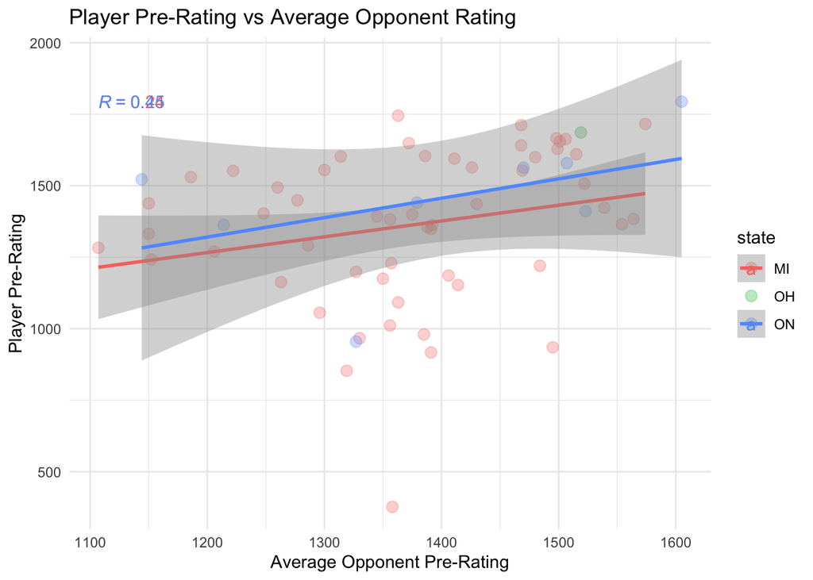

```r
library(ggplot2)
library(dplyr)
library(ggpubr)
players_df %>%
  ggplot(aes(x = avg_opponent_rating, y = pre_rating, color = state)) +
  geom_point(size = 3, alpha = 0.3) +
  geom_smooth(method = "lm") +
  stat_cor(aes(label = ..r.label..),  method =  "pearson",
          label.x = min(players_df$avg_opponent_rating),
          label.y = max(players_df$pre_rating)) +
  labs(
    title = "Player Pre-Rating vs Average Opponent Rating",
    x = "Average Opponent Pre-Rating",
    y = "Player Pre-Rating"
  )+
  theme_minimal()
```

#getting the top 10 players by total point

```r
top10 <- players_df %>%
  arrange(desc(points), desc(pre_rating)) %>%
  select(name, points, pre_rating, avg_opponent_rating) %>%
  head(10)
top10
```

```
##                   name points pre_rating avg_opponent_rating
## 1             GARY HUA    6.0       1794                1605
## 2      DAKSHESH DARURI    6.0       1553                1469
## 3         ADITYA BAJAJ    6.0       1384                1564
## 4  PATRICK H SCHILLING    5.5       1716                1574
## 5           HANSHI ZUO    5.5       1655                1501
## 6          HANSEN SONG    5.0       1686                1519
## 7    GARY DEE SWATHELL    5.0       1649                1372
## 8     EZEKIEL HOUGHTON    5.0       1641                1468
## 9          STEFANO LEE    5.0       1411                1523
## 10           ANVIT RAO    5.0       1365                1554
```

#Calculating the average rating by state

```r
avg_by_state <- players_df %>%
  group_by(state) %>%
  summarise(avg_rating = mean(pre_rating, na.rm = TRUE)) %>%
  arrange(desc(avg_rating))
avg_by_state
```

```
## # A tibble: 3 × 2
##   state avg_rating
##   <chr>      <dbl>
## 1 OH         1686
## 2 ON         1454.
## 3 MI         1362
```

#visualize and analyse

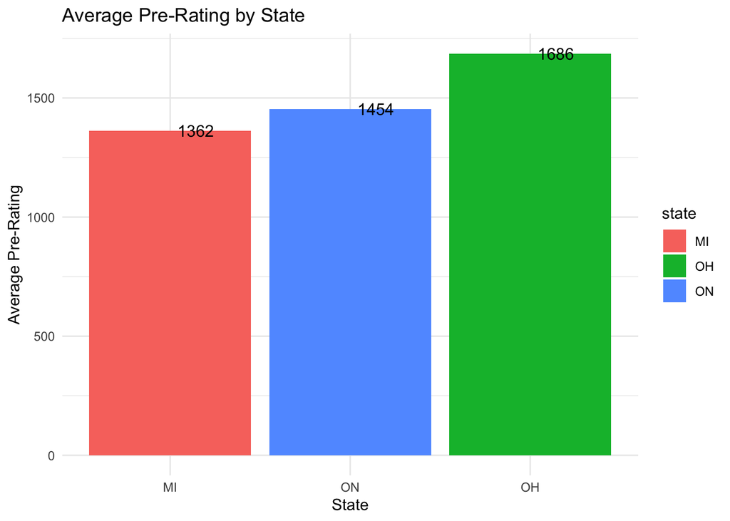

```r
avg_by_state %>%
  ggplot(aes(x = reorder(state, avg_rating), y = avg_rating, fill = state)) +
  geom_bar(stat = "identity") +
  geom_text(aes(label = round(avg_rating, 0)), hjust = -0.2, size = 4) +
  #coord_flip()+
  labs(
    title = "Average Pre-Rating by State",
    x = "State",
    y = "Average Pre-Rating"
  )+
  theme_minimal()
```

#installing packages

```r
library(ggpubr)
library(ggplot2)
library(dplyr)
library(DBI)
library(RSQLite)
```

#Assignement 5B begin here

```r
players_df$expected_score <- sapply(1:nrow(players_df), function(i){
  player_rating <- players_df$pre_rating[i]
  opponent_ids <- players_df$opponents[[i]]


  opponent_ratings <- players_df$pre_rating[
    players_df$player_num %in% opponent_ids
  ]

  expected_each <- 1 / (1 + 10^((opponent_ratings - player_rating)/400))

  sum(expected_each)
})
```

#computing over/under performance of each player

```r
players_df$performance_diff <- players_df$points - players_df$expected_score
```

#selecting the 5 top performers

```r
top_over <- players_df %>%
  arrange(desc(performance_diff)) %>%
  select(name, points, expected_score, performance_diff) %>%
  head(5)
top_over
```

```
##                       name points expected_score performance_diff
## 1             ADITYA BAJAJ    6.0     1.94508791         4.054912
## 2   ZACHARY JAMES HOUGHTON    4.5     1.37330887         3.126691
## 3                ANVIT RAO    5.0     1.94485405         3.055146
## 4 JACOB ALEXANDER LAVALLEY    3.0     0.04324981         2.956750
## 5     AMIYATOSH PWNANANDAM    3.5     0.77345290         2.726547
```

#top 5 underperformes

```r
top_under <- players_df %>%
  arrange(performance_diff) %>%
  select(name, points, expected_score,  performance_diff) %>%
  head(5)
top_under
```

```
##                 name points expected_score performance_diff
## 1   LOREN SCHWIEBERT    3.5       6.275650        -2.775650
## 2 GEORGE AVERY JONES    3.5       6.018220        -2.518220
## 3           JARED GE    3.0       5.010416        -2.010416
## 4       RISHI SHETTY    3.5       5.092465        -1.592465
## 5   JOSHUA DAVID LEE    3.5       4.957890        -1.457890
```

#visualizing performance over plot The analysis reveals that some lower-rated players significantly outperformed expectations, suggesting either strong tournament form or underestimation by their pre-tournament rating. Conversely, several higher-rated players underperformed relative to their expected scores, indicating variance inherent in competitive tournaments.

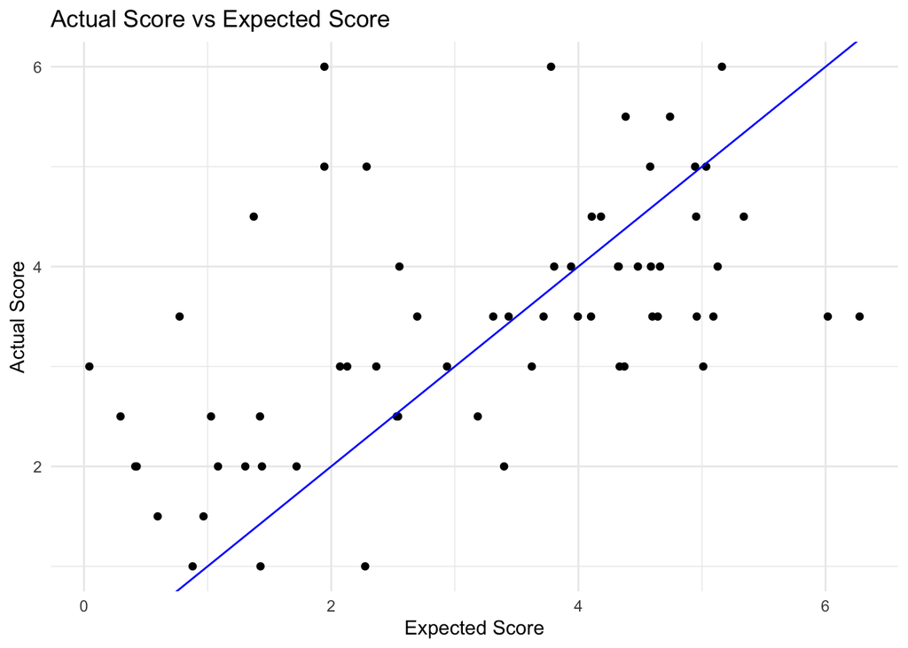

```r
players_df %>%
  ggplot(aes(x = expected_score, y = points)) + geom_point() +
  geom_abline(color = "blue") + labs(
    title = "Actual Score vs Expected Score",
    x = "Expected Score",
    y = "Actual Score"
  ) +
  theme_minimal()
```

#Conclusion

The expected score for each player was calculated using the standard Elo rating formula as defined by Arpad Elo and adopted by FIDE. The model estimates the probability of a player scoring a point against each opponent based on rating differences. Summing these probabilities across all rounds produces the total expected score. Comparing expected scores to actual performance allows identification of players who significantly overperformed or underperformed relative to their rating.